# Which teams Come Alive in March?

Brian Cooper

2023-01-15

### Which types of teams perform best in the NCAA tournament?

Over the course of a season, college basketball teams develop an offensive identity (faster/slower tempo, three-point/post game) but which offensive style can teams rely on when the Big Dance begins? In this analysis, I will attempt to answer this question by creating a score comparing a team’s expected post season performance with their actual performance. I will cross reference this metric with three metrics representing a teams offensive identity 1. a team’s three point percentage 2. offensive rebound rate and 3. tempo (expected possessions per game). Lastly I will examine the relationship between this post season performance metric and a team’s overall defensive ability.

Data acquired from https://www.kaggle.com/datasets/andrewsundberg/college-basketball-dataset?resource=download.

## **Data**

The sample used for this study consisted of the 476 NCAA tournament teams between the years 2013 and 2019. We are interested in post season performance but we want to normalize this performance for how a team was expected to perform. If a 16 seed has a really low 3pt percentage and a 1 seed has a high 3pt percentage, we cannot necessarily attribute their final placement in the tournament to a difference in play style but rather an overall difference in quality. Instead of looking at raw placement as our dependent variable, we will examine a team’s “seeding difference” (SeDi) or the difference between their seed coming into the tournament and their adjusted seed, or the seed their placement would suggest they should have had coming in. For example, making the final four puts you in the top 4 teams of the tournament (theoretically) so your adjusted seed would be a 1, and those teams that go out in the sweet 16 would be treated as 4 seeds coming into the tournament. So a 1 seed going out in the first round would have a seeding difference of **actual seed** - **adjusted seed** or 1 - 16 = -15. And a 7 seed losing in the elite 8 would get a SeDi of 7 - 2 = 5. Positive SeDi’s are teams who outperform their seed coming in and negative SeDi’s under-perform in the tournament.

Let’s look at the breakdown of the SeDi’s:

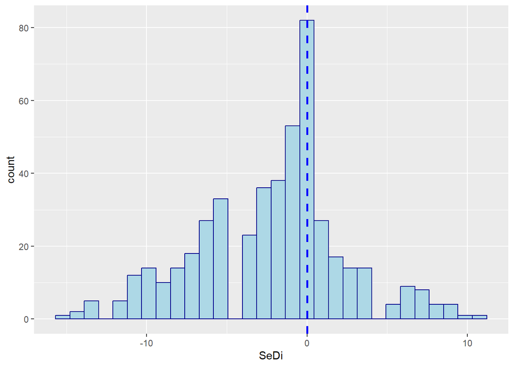

We see that most teams under-perform compared to their seeding coming into the tournament. This makes sense given that the entire range of teams that often lose in the first round (from 9-15 seeds) will all get a negative SeDi value even if they lose when expected because they will be measured against an adjusted seeding of 16.

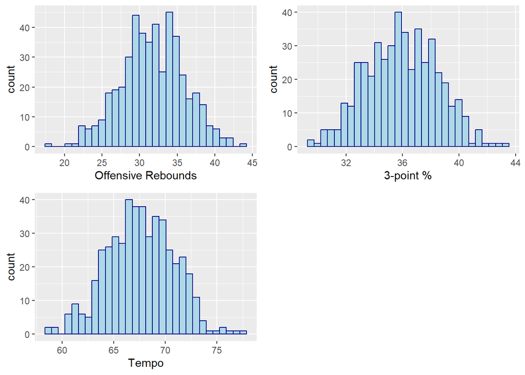

## **Results**

First, let’s look out how teams different aspects of a team’s offensive identity (Offensive rebounds, 3-point percentage, and tempo) can impact their post season performance.

### Offensive Rebounds

First we can try and find an obvious trend in the data.

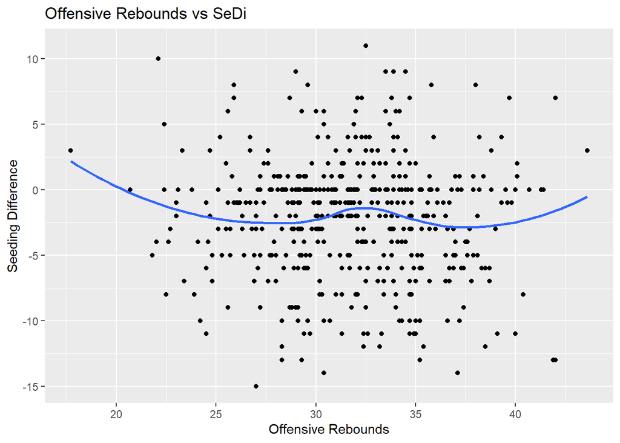

It is hard to tell if there is any real relationship with this plot so let’s try visualizing the data with box plots separated in three groups, teams that met their expected exit, under-performed, and over-performed.

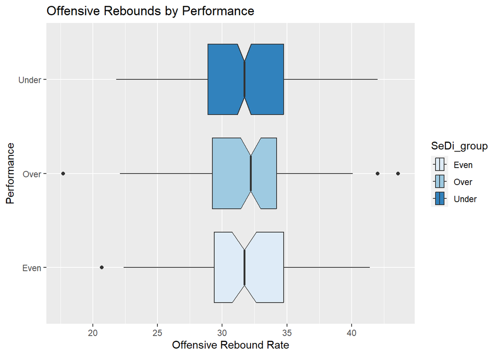

### 3-point Percentage

Now we can do the same visualizations for 3 point percentage.

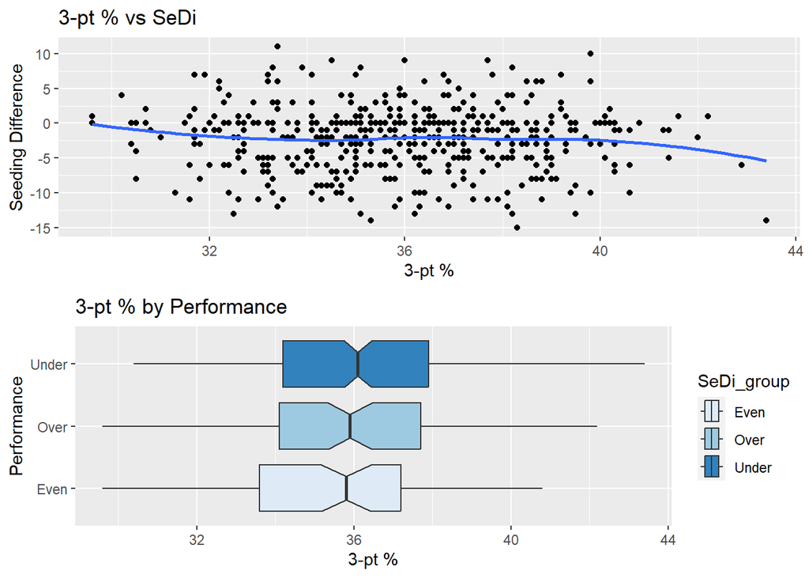

### Tempo

And again for offensive tempo.

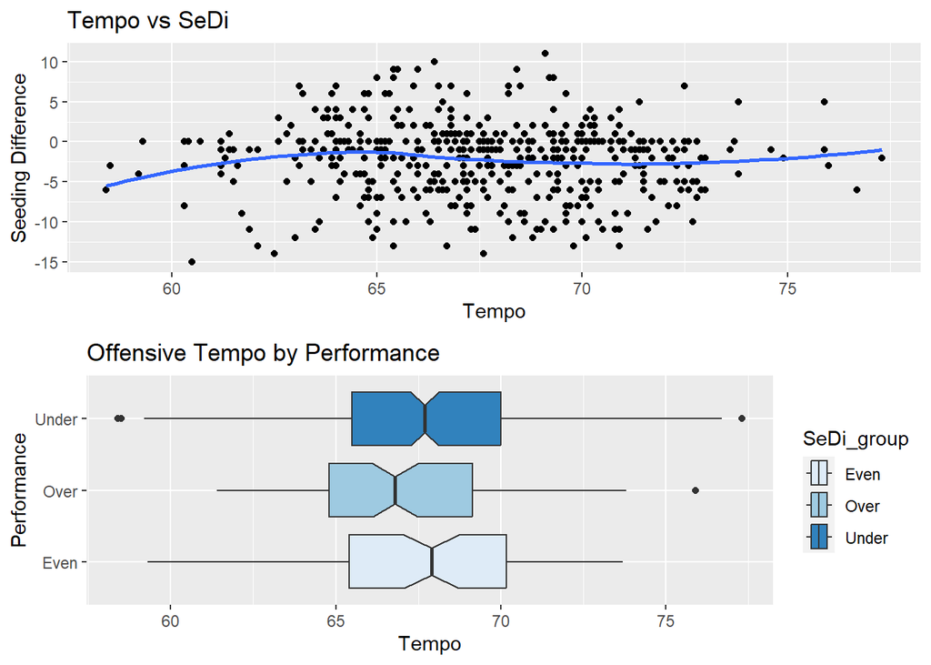

## **Analysis**

Between the different categories of performance, we see small differences in our offensive metrics. It looks like the teams that over-performed in the tournament were teams with slightly higher offensive rebound rates and slightly lower tempo and 3-point percentage. However, given the small differences between the groups, we should perform some sort of test to see if the differences we observed are statistically significant. Thus, we will make a model to predict our SeDi variable based on a combination of offensive and defensive statistics including offensive rebound rate, offensive rebound rate allowed, 2-point percentage, 2-point percentage allowed, turnover rate, steal rate, etc.

```
##
## Call:
## lm(formula = SeDi ~ ., data = tourney[, -c(1, 2, 3, 4, 7, 21,
##     22, 23, 24, 25, 27)])
##
## Residuals:
##      Min       1Q   Median       3Q      Max
## -12.7279  -2.6977   0.2446   2.5775  11.9504
##
## Coefficients:
##               Estimate Std. Error t value Pr(>|t|)
## (Intercept) -15.114857  10.566560  -1.430  0.15327
## ADJOE         0.007591   0.102878   0.074  0.94122
## ADJDE         0.237299   0.117030   2.028  0.04317 *
## EFG_O         0.348717   0.966048   0.361  0.71829
## EFG_D        -2.939342   1.087603  -2.703  0.00713 **
## TOR           0.030831   0.191404   0.161  0.87210
## TORD          0.367196   0.170840   2.149  0.03213 *
## ORB           0.010203   0.089791   0.114  0.90958
## DRB           0.013929   0.106742   0.130  0.89623
## FTR          -0.070502   0.046604  -1.513  0.13103
## FTRD         -0.024966   0.046735  -0.534  0.59346
## `2P_O`       -0.075062   0.615109  -0.122  0.90293
## `2P_D`        1.825885   0.693953   2.631  0.00880 **
## `3P_O`       -0.284559   0.504450  -0.564  0.57296
## `3P_D`        1.352802   0.561673   2.409  0.01641 *
## ADJ_T        -0.141285   0.072312  -1.954  0.05133 .
## ---
## Signif. codes:  0 '***' 0.001 '**' 0.01 '*' 0.05 '.' 0.1 ' ' 1
##
## Residual standard error: 4.511 on 460 degrees of freedom
## Multiple R-squared:  0.07127,    Adjusted R-squared:  0.04098
## F-statistic: 2.353 on 15 and 460 DF,  p-value: 0.00291
```

## **Conclusion**

Another potential explanation for this analysis is not so much an examination of the game-play but an indictment on the seeding system itself. There is a chance that the seeding committee may systematically underrate defensively sound teams because their offensive output does not stand out as much as better shooting teams. Both o these interpretations of the results can be true. It seems that the NCAA tournament can expose teams without the defensive acumen to compete for tough wins but it can also provide a chance for teams overlooked by the committee to grind out wins no one expected of them.